# Your Digest for Friday, Mar 22, 2024 11:59 PM

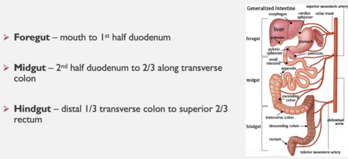

# Drugs causing photosensitive rashes

> [!INFO] Mnemonic: SNAP-DCS

[figure not shown]

For a complete list: [Source](https://emedicine.medscape.com/article/1049648-overview)

Passmedicine:

- Sulphonylureas
- NSAIDS (piroxicam)
- Amiodarone
- Psoralens
- Thiazides
- Ciprofloxacin, Tetratyclines (Doxy), sulphonamides

# Causes of renal papillary necrosis (RPN)

[Source](https://emedicine.medscape.com/article/439586-overview#a8)

> [!TIP] Mnemonic : POSTCARDS
> 1. Pyelonephritis
> 2. Obstruction
> 3. Sickle cell disease
> 4. Tuberculosis
> 5. Cirrhosis, chronic alcoholism
> 6. Analgesic abuse
> 7. Renal transplant rejection
> 8. Diabetes mellitus
> 9. Systemic vasculitis
- Renal papillary necrosis is coagulative necrosis of the renal papilla (the apex of the renal pyramid) secondary to ischemia.
- It may occur as a complication of severe pyelonephritis but it does not always follow infection.
- papillary necrosis can predispose to infection of the necrotic site or act as a focus for calculus formation.
- The papillae have a poor blood supply despite being supplied by the vasa recta (arising from the efferent arterioles) and the interlobar branches of the renal artery.
- RPN is easily induced experimentally by administering a combination of aspirin (inhibits PGE) and phenacetin (highyy nephrotoxic)

#2015MCQ-APR/Q04

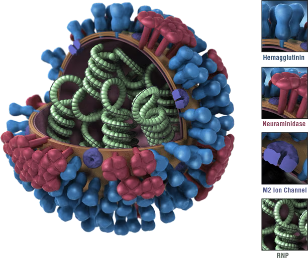

Enveloped, single stranted RNA virus.  
It can survive for several hours on fomites. (upto 48) [Source](https://pubmed.ncbi.nlm.nih.gov/6282993/)

**Symptoms**:

- *Uncomplicated disease*
  - Fever, corrhyzal symptoms
  - Constitutional symptoms
  - Red and watery eyes
  - *Non productive* Cough
  - Sore throat
- Older adults and immunosuppresed patients may have fewer symptoms but *confusion* is commoner among *older patients*.
- ⭐Physical examination of the lungs **is normal**

**Complicated disease**

- **Pneumonia** - usually occurs within a few days of onset: *cough becomes purulent* and productive. Commonest cause is *Strep. pneumoniae*. [Source](https://www.ncbi.nlm.nih.gov/pmc/articles/PMC5481322/)
- **Myocarditis**, pericarditis, myocardial infarction, CNS involvement, myositis, rhabdomyolysis can all occur.
- **CNS**: Seizures, *encephalitis*, *Guillain barre* syndrome,
  - It can also cause a *parkinson like* syndrome called "*encephalitis lethargica*" [Source](https://www.ncbi.nlm.nih.gov/pmc/articles/PMC4942044/)

**Why is vaccination so common?**

**Transmission** - very high risk because:

- Incubation period - 2 days; but *transmission can occur before symptoms onset* and even from asymptomatic persons.  
  **Diagnosis**:
- Usually clinical but if necessary, *viral culture from nasopharyngeal swabs* is the gold standard. Antigen kits are specific but *not very sensitive*.
- Mainstay is prevention with the vaccine; new vaccines are now *quadrivalent*. (2 A subtypes and 2 B subtypes)
- Vaccination is *recommended for any trimester* of pregnancy. It also confirs protection to the newborn.
  - Oseltamivir *reduces duration of symptoms* and *duration of viral shedding*.
  - Treatment duration is *5 days*.
- *Vaccines are the best method of prevention*. However, if vaccine is contraindicated or ineffective (patient is immunosuppresed), antivirals (oseltamivir) can be used for *prophylaxis*.
- Other drugs include Amantadine (yes.. antiparkinsons drug) and rimantadine which blocks the viral M2 proton channel but there is not high resistance to these drugs (in the USA) so not recommended for use there.

## Antigenic drift and antigenic shift

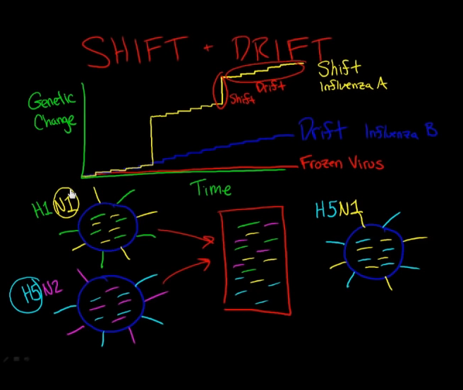

[figure not shown]

# ⭐Ethylene glycol poisoning

> - Calcium oxalate crystals form -> hypocalcaemia.

> [!TIP] Mnemonic:
> - Terlipressin - **T for tight** -> tightens the blood vessels (pressor)
> - Desmoressin - **D for 'anti'-Diuresis**

| Vasopressin | Desmopressin | Terlipressin | felypressin |
| --- | --- | --- | --- |
| *Short duration* | **Longer** duration | **Longer** duration | Short acting |
| Weakly V2 selective | V2 selective; *mainly antiuretic action* | V1: *mainly pressor action* | vasocontrictor |
|  | ☝️*Less pressor action* | minimal V2 action | Used to prolong local anaesthetic action |

- Considered the second most toxic herbicide in Sri Lanka after paraquat.
- Apparently DSH with propanil is quite common.

> [!INFO] Further Reading: Skip  
> Compounds with high hepatic extraction show clearance rates that are directly dependent on hepatic blood flow. If fewer compounds are delivered to the liver, fewer compounds are removed from the circulation. In contrast, generally, compounds with lower extraction ratios tend to be blood flow independent [Source](https://www.ncbi.nlm.nih.gov/books/NBK53072/)